# Lab 8: The 12 Days of Christmas

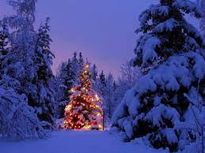

## 0.1 Singing the Song

Alright, so you’ve already created two helper functions, `pluralize_gift()` and `make_phrase()`, which you used at the end of the Practice Activity to create a column of song phrases / lines.

Today, you will use these phrases to write a function which sings the lines of song for a given day. We will then use this function to iterate through the 12 days of Christmas to get our song!

**Danger**

Note, you will either need to copy over your functions from the Practice Activity into your new Quarto document or continue working in the Quarto file from the Practice Activity.

Specifically, this stage requires that you generated a `Full.Phrase` column using `pmap_chr()`.

# 1 Step Three: Iteration.

Write a function called `sing_day()` that takes as input:

- A dataset (input as a dataframe)
- A number indicating which day to sing about (input as an integer)
- The name of a column in the dataset that contains the phrases for each day (input as an **tidy** name)

For example,

```
sing_day(xmas2, 2, Full.Phrase)
```

should return

```
On the second day of Christmas, my true love sent to me:
two turtle doves and
a partridge in a pear tree.
```

**Tip**

**Extracting the phrases** The `{{phrase_col}}` part, which I provided for you, lets you use column names as arguments to a function. **Do not** delete that line of code!

**Getting the days**  
The `ordinal()` function from the **english** package could be helpful when converting the `line` input (e.g., 1) to a word (e.g., “first”).

**Danger**

**Iteration inside the function** There **should not** be iteration *inside* your function. We will use iteration *outside* the function, to sing each day of the song.

**Singing all the gifts** *Remember, each day, you get the gift for that day* and* all the prior days. Also, remember that these gifts go in reverse order! (e.g., two turtle doves and a partridge in a pear tree).

```r
# Produces the string for one day of the song.
# Arguments -- dataset: A data frame containing information about gifts
# Arguments -- line: The number of the line for the day you want to sing about
# Arguments -- phrase_col: The variable name for the column in the dataset that contains the song phrases
# Return -- A string singing the line of the song with all gifts for the given day.

sing_day <- function(dataset, line, phrase_col){

  # Step 1: Setup the intro line
  # Hint: You need to convert a number (e.g., 1) to a word (e.g., first)
  num_word <- ____

  intro <- glue::glue("On the {num_word} day of Christmas")

  # Step 2: Sing the gift phrases

    phrases <- dataset |>
      pull( {{phrase_col}} )

  ????

  ## put it together

  ????

}
```

## 1.1 A Small Test

```r
xmas2 |>
sing_line(num = 2, phrase_col = Full.Phrase)
```

# 2 Step Four: Use Your Functions!

**What `map()` function to use?**

What type of output are you expecting? A vector of numbers? A vector of characters? A dataframe? A list?

You might find the lecture slides from Tuesday helpful when completing this task!

**`for()`-loops**

You are not permitted to use a `for()`-loop to complete this task.

## 2.1 Submission

You Lab 8 submission **must** have individual sections (with headers) for each function you’ve written (e.g., Pluralize Gifts, Sing Phrases, Sing Song), with the code for each function visible to the reader.

As stated for previous Lab & Challenge submissions, your HTML file is required to have the following specifications in the YAML options (at the top of your document):

- be self-contained (`self-contained: true`)
- include your source code (`code-tools: true`)
- include all your code and output (`echo: true`)
- include **no** messages (`messages: false`) or warnings (`warnings: false`) from loading in packages or the data

**If any of the options are not included, your Lab 8 or Challenge 8 assignment will receive an “Incomplete” and you will be required to submit a revision for the formatting of your submission.**

## 2.2 Revisions

**You will get an automatic revision for:**

- Functions that do not work the way they are intended
- “Hard-Coding” in functions.
- Not using `pmap_chr()` to obtain your phrases
- Not using a `map()` function to iterate your function

# 3 Challenge – Styling Your Song

**Build off your Lab 8 submission**

Your Challenge 8 submission can be identical to your Lab 8 submission, with the additional modifications you made to format the appearance of your lyrics.

## 3.1 Option 1 – Removing Whitespace

Remove any additional spaces between words, such that there should only be **one** whitespace character between words and **no** whitespace at the beginning or end of each phrase.

## 3.2 Option 2 – New Lines for Gifts

```
On the second day of Christmas, my true love gave to me:
two turtle doves and
a partridge in a pear tree
```

## 3.3 Option 3 – Spaces Between Days

Ensure there are blank spaces between the different lines of the song. For example, when iterating your function, your output should look like the following:

```
On the second day of Christmas, my true love gave to me:
two turtle doves and
a partridge in a pear tree

On the first day of Christmas, my true love gave to me:
a partridge in a pear tree
```

## 3.4 Option 4 – Getting Grammatical

Ensure the lines of your song are grammatically correct. There are three components you should address in making your lines grammatically correct:

1. Use of Commas – each line should end in a comma *except* for the last line
2. Use of And – there should be an “and” included *either* at the end of the second to last line *or* at the beginning of the final line
3. Use of Period – there should be a period at the end of the final line

```
On the third day of Christmas, my true love gave to me:
three french hens,
two turtle doves, and
a partridge in a pear tree.
```

**Oxford Comma**

While I am a fan of the oxford comma, you do not have to use an oxford comma for the second to last phrase of your song.